# Exploring the state of transitional care in pediatric pilocytic astrocytoma data analysis

Shuting Mao

2024-12-01

# Introduction

Pediatric pilocytic astrocytoma (PPA) requires prolonged follow-up after initial resection. The landscape of transitional care for PPA patients is not well characterized. The authors sought to examine the clinical course and transition to adult care for these patients to better characterize opportunities for improvement in long-term care. The analysis will focus on creating descriptive summaries, performing group comparisons (e.g., pediatric vs. adult patients), and presenting these findings in a series of tables and figures to better illustrate the clinical landscape and care transitions for PPA patients. Key insights will be derived from both statistical tests and visualizations (bar charts, pie charts, etc.) to provide a comprehensive overview of the long-term care needs of this patient population.

# Data Loading

First, we will load the dataset.

# descriptive analysis

Table 1 presents the demographic characteristics of the pediatric and adult groups within the study cohort, focusing on key variables such as gender, race, and age at diagnosis. The results are displayed as counts and percentages for categorical variables (e.g., gender and race) and as means with standard deviations for continuous variables (e.g., age at diagnosis).

For each variable, the table compares the pediatric and adult groups and provides the p-values resulting from statistical tests (Chi-squared test for categorical variables and a two-sample t-test for continuous variables). This table aims to highlight any significant differences between the two groups.

Demographics by Pediatric and Adult Group

[output not shown]

Note:  
Values are presented as n (%) or mean ± SD.

# Graphical Analysis

The bar chart presents the distribution of tumor locations across pediatric and adult patients. The x-axis lists the tumor locations, including “Posterior Fossa,” “Brainstem,” “Cerebral Cortex,” “Suprasellar,” and “Optic Nerve.” The y-axis shows the count of patients in each group for the respective tumor locations. The blue bars represent pediatric patients, while the red bars represent adult patients.

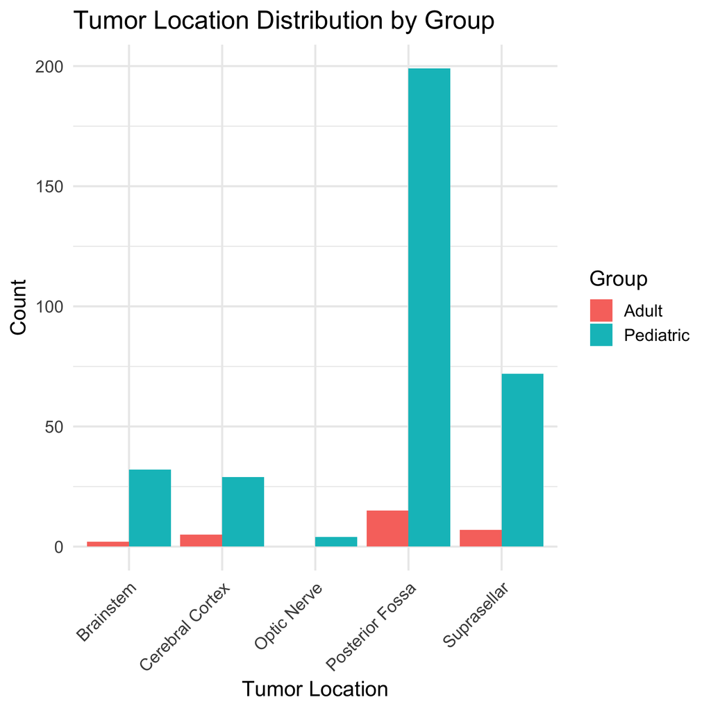